# Data MPDW

Indah Dzulkharifah

2025-08-30

Packages

```r
library("forecast")
```

```r
library("graphics")
library("TTR")
library("TSA")
library("readxl")
```

Import Data

```r
dt <- read_excel("C:/Users/USER/Downloads/Indah.xlsx")
dt
```

```
## # A tibble: 250 × 2
##    date                temp_mean
##    <dttm>                  <dbl>
##  1 2023-08-08 00:00:00      26.8
##  2 2023-08-09 00:00:00      26.7
##  3 2023-08-10 00:00:00      26.4
##  4 2023-08-11 00:00:00      26.7
##  5 2023-08-12 00:00:00      26.5
##  6 2023-08-13 00:00:00      26.4
##  7 2023-08-14 00:00:00      27
##  8 2023-08-15 00:00:00      27.1
##  9 2023-08-16 00:00:00      27.3
## 10 2023-08-17 00:00:00      27.2
## # ℹ 240 more rows
```

Data yang digunakan adalah data rataan temperatur di Kab. Bogor, data merupakan data perhari dimulai dari rentang waktu **08 Agustus 2023 hingga 13 April 2024**

Eksplorasi Data

```r
View(dt)
str(dt)
```

```
## tibble [250 × 2] (S3: tbl_df/tbl/data.frame)
##  $ date     : POSIXct[1:250], format: "2023-08-08" "2023-08-09" ...
##  $ temp_mean: num [1:250] 26.8 26.7 26.4 26.7 26.5 26.4 27 27.1 27.3 27.2 ...
```

```r
dim(dt)
```

```
## [1] 250   2
```

Mengubah data agar terbaca sebagai data deret waktu dengan fungsi ts()

```r
dt.ts <- ts(dt$temp_mean)
```

Menampilkan ringkasan data

```r
summary(dt.ts)
```

```
##    Min. 1st Qu.  Median    Mean 3rd Qu.    Max.
##   24.90   26.00   26.70   26.77   27.50   29.10
```

Membuat plot data deret waktu

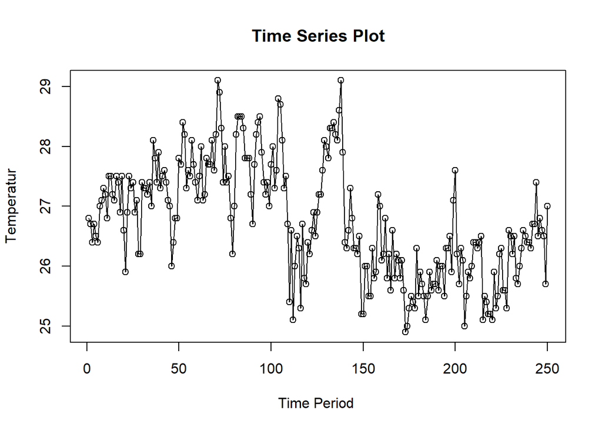

```r
ts.plot(dt.ts, xlab="Time Period ", ylab="Temperatur",
        main = "Time Series Plot")
points(dt.ts)
```

Single Moving Average

Pembagian Data

Pembagian data latih dan data uji dilakukan dengan perbandingan 80% data latih dan 20% data uji.

```r
# hitung jumlah data
n <- nrow(dt)

# tentukan batas 80%
n_train <- floor(0.8 * n)

# bagi data
training_ma <- dt[1:n_train, ]
testing_ma  <- dt[(n_train+1):n, ]

# ubah ke time series
train_ma.ts <- ts(training_ma$temp_mean)
test_ma.ts  <- ts(testing_ma$temp_mean)
```

Data Keseluruhan

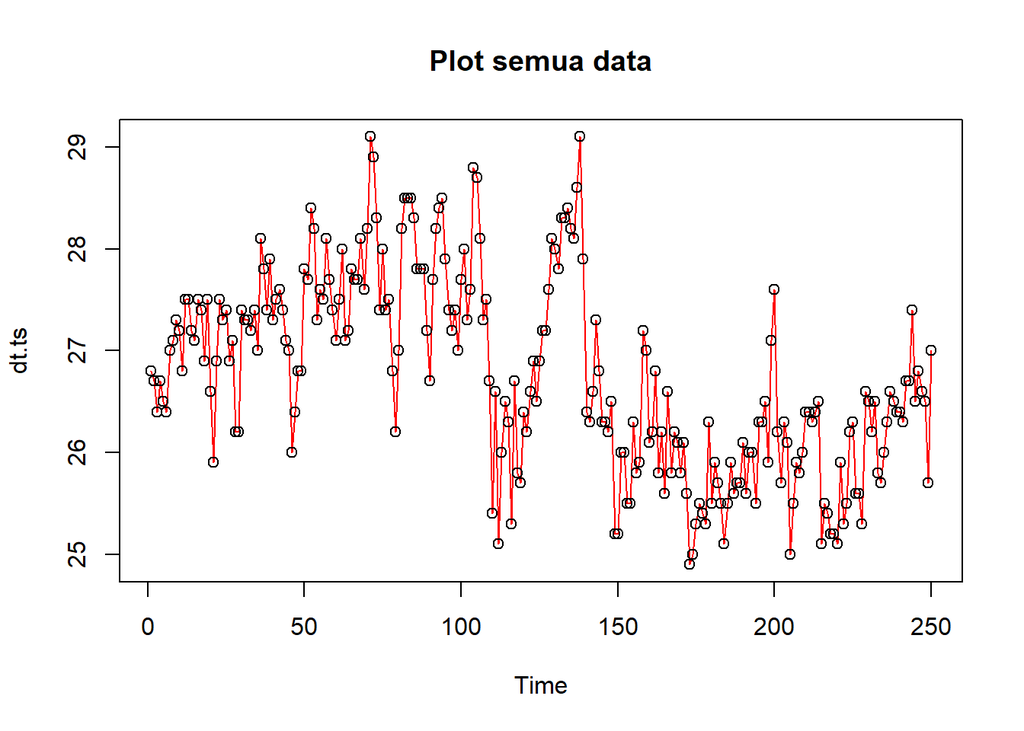

```r
#eksplorasi keseluruhan data
plot(dt.ts, col="red",main="Plot semua data")
points(dt.ts)
```

Data Latih

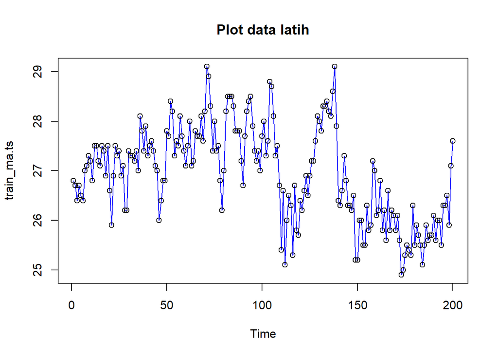

```r
#eksplorasi data latih
plot(train_ma.ts, col="blue",main="Plot data latih")
points(train_ma.ts)
```

Data Uji

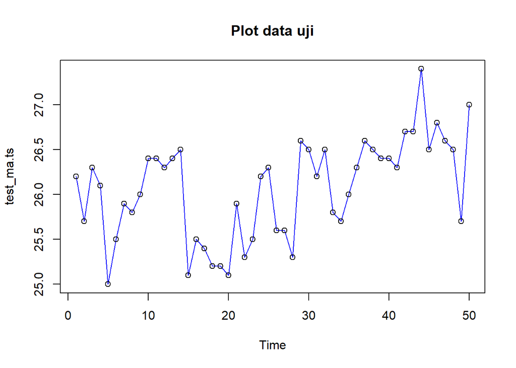

```r
#eksplorasi data uji
plot(test_ma.ts, col="blue",main="Plot data uji")
points(test_ma.ts)
```

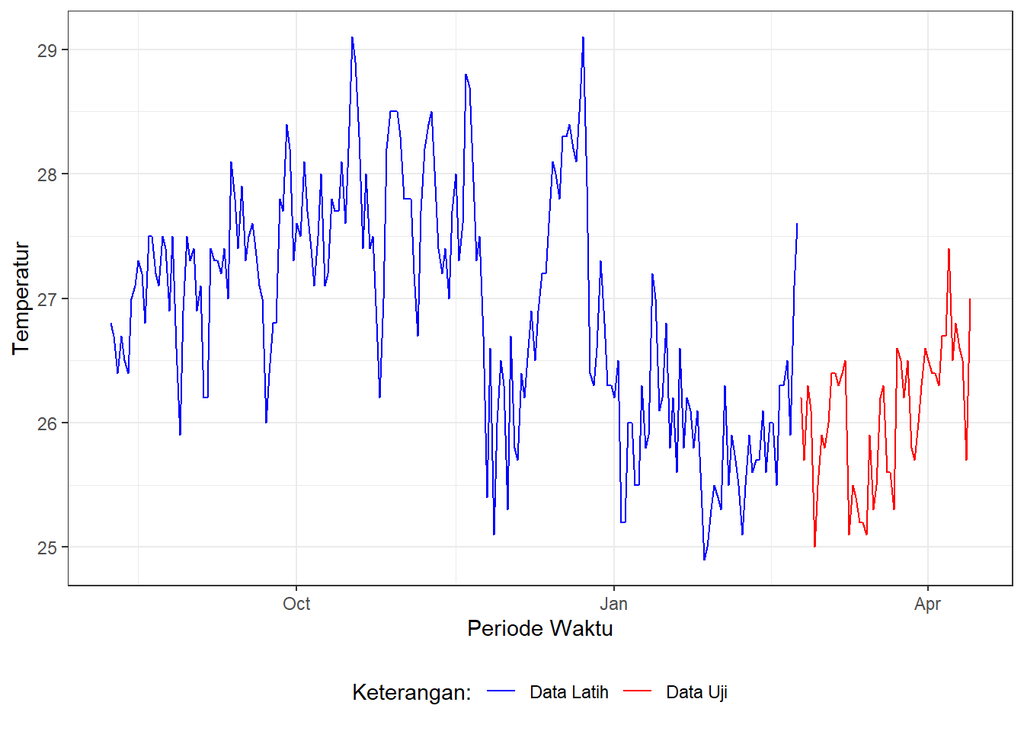

```r
library(ggplot2)
ggplot() +
  geom_line(data = training_ma, aes(x = date, y = temp_mean, col = "Data Latih")) +
  geom_line(data = testing_ma, aes(x = date, y = temp_mean, col = "Data Uji")) +
  labs(x = "Periode Waktu", y = "Temperatur", color = "Legend") +
   scale_colour_manual(name="Keterangan:", breaks = c("Data Latih", "Data Uji"),
                      values = c("blue", "red")) +
  theme_bw() + theme(legend.position = "bottom",
                     plot.caption = element_text(hjust=0.5, size=12))
```

Pemulusan menggunakan metode SMA dilakukan dengan fungsi **SMA()**. Prinsip dasar metode pemulusan ini adalah data pemulusan pada periode ke-t merupakan rata rata dari m buah data pada periode ke-t hingga periode ke (t-m+1).

```r
data.sma<-SMA(train_ma.ts, n=4)
data.sma
```

```
## Time Series:
## Start = 1
## End = 200
## Frequency = 1
##   [1]     NA     NA     NA 26.650 26.575 26.500 26.650 26.750 26.950 27.150
##  [11] 27.100 27.200 27.250 27.250 27.325 27.325 27.300 27.225 27.325 27.100
##  [21] 26.725 26.725 26.725 26.900 27.275 27.275 27.175 26.900 26.600 26.725
##  [31] 26.775 27.050 27.300 27.300 27.225 27.425 27.575 27.575 27.800 27.600
##  [41] 27.525 27.575 27.450 27.400 27.275 26.875 26.625 26.550 26.500 26.950
##  [51] 27.275 27.675 28.025 27.900 27.875 27.650 27.625 27.725 27.675 27.575
##  [61] 27.425 27.500 27.425 27.450 27.525 27.450 27.600 27.825 27.775 27.900
##  [71] 28.250 28.450 28.625 28.425 28.150 27.775 27.575 27.425 26.975 26.875
##  [81] 27.050 27.475 28.050 28.425 28.450 28.275 28.100 27.925 27.650 27.375
##  [91] 27.350 27.450 27.750 28.200 28.250 28.050 27.750 27.475 27.250 27.325
## [101] 27.525 27.500 27.650 27.925 28.100 28.300 28.225 27.900 27.400 26.725
## [111] 26.550 25.950 25.775 26.050 25.975 26.025 26.200 26.025 25.875 26.150
## [121] 26.025 26.225 26.525 26.550 26.725 26.875 26.950 27.225 27.525 27.725
## [131] 27.875 28.050 28.100 28.200 28.300 28.250 28.325 28.500 28.425 28.000
## [141] 27.425 26.800 26.650 26.750 26.750 26.675 26.400 26.325 26.050 25.775
## [151] 25.725 25.600 25.675 25.750 25.825 25.775 25.875 26.300 26.475 26.550
## [161] 26.625 26.525 26.225 26.250 26.100 26.050 26.050 26.050 26.175 25.975
## [171] 26.050 25.900 25.600 25.400 25.200 25.175 25.300 25.375 25.625 25.625
## [181] 25.750 25.850 25.650 25.550 25.450 25.500 25.525 25.675 25.725 25.775
## [191] 25.775 25.850 25.925 25.775 25.950 26.025 26.150 26.250 26.450 26.775
```

Data pemulusan pada periode ke-t selanjutnya digunakan sebagai nilai peramalan pada periode ke t+1 sehingga hasil peramalan 1 periode kedepan adalah sebagai berikut.

```r
data.ramal<-c(NA,data.sma)
data.ramal #forecast 1 periode ke depan
```

```
##   [1]     NA     NA     NA     NA 26.650 26.575 26.500 26.650 26.750 26.950
##  [11] 27.150 27.100 27.200 27.250 27.250 27.325 27.325 27.300 27.225 27.325
##  [21] 27.100 26.725 26.725 26.725 26.900 27.275 27.275 27.175 26.900 26.600
##  [31] 26.725 26.775 27.050 27.300 27.300 27.225 27.425 27.575 27.575 27.800
##  [41] 27.600 27.525 27.575 27.450 27.400 27.275 26.875 26.625 26.550 26.500
##  [51] 26.950 27.275 27.675 28.025 27.900 27.875 27.650 27.625 27.725 27.675
##  [61] 27.575 27.425 27.500 27.425 27.450 27.525 27.450 27.600 27.825 27.775
##  [71] 27.900 28.250 28.450 28.625 28.425 28.150 27.775 27.575 27.425 26.975
##  [81] 26.875 27.050 27.475 28.050 28.425 28.450 28.275 28.100 27.925 27.650
##  [91] 27.375 27.350 27.450 27.750 28.200 28.250 28.050 27.750 27.475 27.250
## [101] 27.325 27.525 27.500 27.650 27.925 28.100 28.300 28.225 27.900 27.400
## [111] 26.725 26.550 25.950 25.775 26.050 25.975 26.025 26.200 26.025 25.875
## [121] 26.150 26.025 26.225 26.525 26.550 26.725 26.875 26.950 27.225 27.525
## [131] 27.725 27.875 28.050 28.100 28.200 28.300 28.250 28.325 28.500 28.425
## [141] 28.000 27.425 26.800 26.650 26.750 26.750 26.675 26.400 26.325 26.050
## [151] 25.775 25.725 25.600 25.675 25.750 25.825 25.775 25.875 26.300 26.475
## [161] 26.550 26.625 26.525 26.225 26.250 26.100 26.050 26.050 26.050 26.175
## [171] 25.975 26.050 25.900 25.600 25.400 25.200 25.175 25.300 25.375 25.625
## [181] 25.625 25.750 25.850 25.650 25.550 25.450 25.500 25.525 25.675 25.725
## [191] 25.775 25.775 25.850 25.925 25.775 25.950 26.025 26.150 26.250 26.450
## [201] 26.775
```

Selanjutnya dilakukan peramalan sebanyak 50 periode sesuai dengan jumlah data uji. Pada metode SMA, seluruh hasil peramalan untuk 50 periode ke depan akan memiliki nilai yang sama dengan hasil ramalan satu periode ke depan.

```r
data.gab<-cbind(
  aktual=c(dt.ts),
  pemulusan=c(data.sma,rep(NA,50)),
  ramalan=c(data.ramal,rep(data.ramal[length(data.ramal)],49)))

data.gab #forecast 50 periode ke depan
```

```
##        aktual pemulusan ramalan
##   [1,]   26.8        NA      NA
##   [2,]   26.7        NA      NA
##   [3,]   26.4        NA      NA
##   [4,]   26.7    26.650      NA
##   [5,]   26.5    26.575  26.650
##   [6,]   26.4    26.500  26.575
##   [7,]   27.0    26.650  26.500
##   [8,]   27.1    26.750  26.650
##   [9,]   27.3    26.950  26.750
##  [10,]   27.2    27.150  26.950
##  [11,]   26.8    27.100  27.150
##  [12,]   27.5    27.200  27.100
##  [13,]   27.5    27.250  27.200
##  [14,]   27.2    27.250  27.250
```

[output cut: 236 more lines]

Plot Data Deret Waktu dari Hasil Peramalan

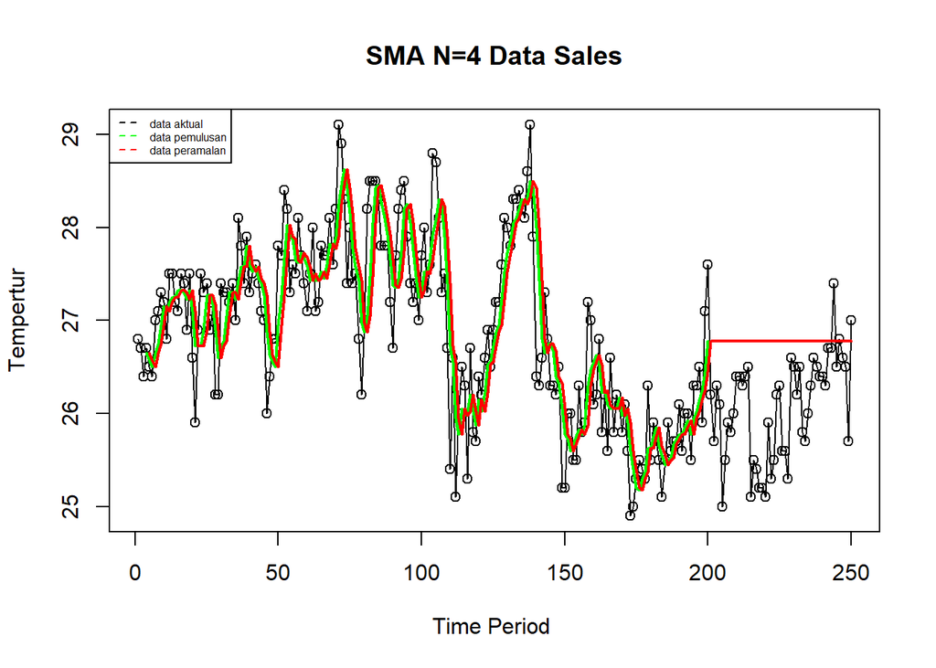

```r
ts.plot(dt.ts, xlab="Time Period ", ylab="Tempertur", main= "SMA N=4 Data Sales")
points(dt.ts)
lines(data.gab[,2],col="green",lwd=2)
lines(data.gab[,3],col="red",lwd=2)
legend("topleft",c("data aktual","data pemulusan","data peramalan"), lty=8, col=c("black","green","red"), cex=0.5)
```

Akurasi Data Latih

```r
#Menghitung nilai keakuratan data latih
error_train.sma = train_ma.ts-data.ramal[1:length(train_ma.ts)]

SSE_train.sma = sum(error_train.sma[5:length(train_ma.ts)]^2)
MSE_train.sma = mean(error_train.sma[5:length(train_ma.ts)]^2)
MAPE_train.sma = mean(abs((error_train.sma[5:length(train_ma.ts)]/train_ma.ts[5:length(train_ma.ts)])*100))

akurasi_train.sma <- matrix(c(SSE_train.sma, MSE_train.sma, MAPE_train.sma))
row.names(akurasi_train.sma)<- c("SSE", "MSE", "MAPE")
colnames(akurasi_train.sma) <- c("Akurasi m = 4")
akurasi_train.sma
```

```
##      Akurasi m = 4
## SSE     74.8950000
## MSE      0.3821173
## MAPE     1.8069617
```

Dalam hal ini nilai MAPE data latih pada metode pemulusan SMA sekitar **<2%**, nilai ini dapat dikategorikan sebagai nilai akurasi yang **sangat baik**.

Akurasi Data Uji

```r
#Menghitung nilai keakuratan data uji
error_test.sma = test_ma.ts-data.gab[201:250,3]

SSE_test.sma = sum(error_test.sma^2)
MSE_test.sma = mean(error_test.sma^2)
MAPE_test.sma = mean(abs((error_test.sma/test_ma.ts*100)))

akurasi_test.sma <- matrix(c(SSE_test.sma, MSE_test.sma, MAPE_test.sma))
row.names(akurasi_test.sma)<- c("SSE", "MSE", "MAPE")
colnames(akurasi_test.sma) <- c("Akurasi m = 4")
akurasi_test.sma
```

```
##      Akurasi m = 4
## SSE      39.981250
## MSE       0.799625
## MAPE      2.885945
```

Perhitungan akurasi menggunakan data uji menghasilkan nilai MAPE yang kurang dari **10%** sehingga nilai akurasi ini dapat dikategorikan sebagai **sangat baik**.

Double Moving Average

Metode pemulusan Double Moving Average (DMA) pada dasarnya mirip dengan SMA. Namun demikian, metode ini lebih cocok digunakan untuk **pola data trend**. Proses pemulusan dengan rata rata dalam metode ini dilakukan sebanyak 2 kali.

```r
dma <- SMA(data.sma, n = 4)
At <- 2*data.sma - dma
Bt <- 2/(4-1)*(data.sma - dma)
data.dma<- At+Bt
data.ramal2<- c(NA, data.dma)

t = 1:50
f = c()

for (i in t) {
  f[i] = At[length(At)] + Bt[length(Bt)]*(i)
}

data.gab2 <- cbind(aktual = c(dt.ts),
                   pemulusan1 = c(data.sma,rep(NA,50)),
                   pemulusan2 = c(dma, rep(NA,50)),
                   At = c(At, rep(NA,50)),
                   Bt = c(Bt,rep(NA,50)),
                   ramalan = c(data.ramal2, f[-1]))
data.gab2
```

```
##        aktual pemulusan1 pemulusan2       At            Bt  ramalan
##   [1,]   26.8         NA         NA       NA            NA       NA
##   [2,]   26.7         NA         NA       NA            NA       NA
##   [3,]   26.4         NA         NA       NA            NA       NA
##   [4,]   26.7     26.650         NA       NA            NA       NA
##   [5,]   26.5     26.575         NA       NA            NA       NA
##   [6,]   26.4     26.500         NA       NA            NA       NA
##   [7,]   27.0     26.650   26.59375 26.70625  3.750000e-02       NA
##   [8,]   27.1     26.750   26.61875 26.88125  8.750000e-02 26.74375
##   [9,]   27.3     26.950   26.71250 27.18750  1.583333e-01 26.96875
##  [10,]   27.2     27.150   26.87500 27.42500  1.833333e-01 27.34583
##  [11,]   26.8     27.100   26.98750 27.21250  7.500000e-02 27.60833
##  [12,]   27.5     27.200   27.10000 27.30000  6.666667e-02 27.28750
##  [13,]   27.5     27.250   27.17500 27.32500  5.000000e-02 27.36667
##  [14,]   27.2     27.250   27.20000 27.30000  3.333333e-02 27.37500
```

[output cut: 236 more lines]

Hasil pemulusan Menggunakan Metode DMA

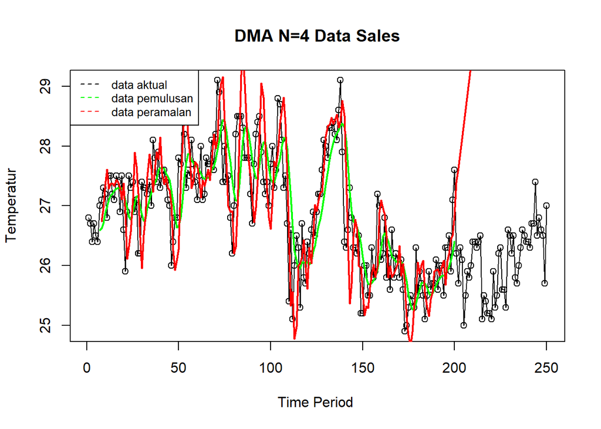

```r
ts.plot(dt.ts, xlab="Time Period ", ylab="Temperatur", main= "DMA N=4 Data Sales")
points(dt.ts)
lines(data.gab2[,3],col="green",lwd=2)
lines(data.gab2[,6],col="red",lwd=2)
legend("topleft",c("data aktual","data pemulusan","data peramalan"), lty=8, col=c("black","green","red"), cex=0.8)
```

Akurasi Data Latih

```r
#Menghitung nilai keakuratan data latih
error_train.dma = train_ma.ts-data.ramal2[1:length(train_ma.ts)]

SSE_train.dma = sum(error_train.dma[8:length(train_ma.ts)]^2)
MSE_train.dma = mean(error_train.dma[8:length(train_ma.ts)]^2)
MAPE_train.dma = mean(abs((error_train.dma[8:length(train_ma.ts)]/train_ma.ts[8:length(train_ma.ts)])*100))

akurasi_train.dma <- matrix(c(SSE_train.dma, MSE_train.dma, MAPE_train.dma))
row.names(akurasi_train.dma)<- c("SSE", "MSE", "MAPE")
colnames(akurasi_train.dma) <- c("Akurasi m = 4")
akurasi_train.dma
```

```
##      Akurasi m = 4
## SSE      92.224470
## MSE       0.477847
## MAPE      2.028496
```

Perhitungan akurasi pada data latih menggunakan nilai MAPE menghasilkan nilai MAPE **sekitar 2%** sehingga dikategorikan **sangat baik**.

Akurasi Data Uji

```r
#Menghitung nilai keakuratan data uji
error_test.dma = test_ma.ts-data.gab2[201:250,6]
SSE_test.dma = sum(error_test.dma^2)
MSE_test.dma = mean(error_test.dma^2)
MAPE_test.dma = mean(abs((error_test.dma/test_ma.ts*100)))

akurasi_test.dma <- matrix(c(SSE_test.dma, MSE_test.dma, MAPE_test.dma))
row.names(akurasi_test.dma)<- c("SSE", "MSE", "MAPE")
colnames(akurasi_test.dma) <- c("Akurasi m = 4")
akurasi_test.dma
```

```
##      Akurasi m = 4
## SSE     3246.49963
## MSE       64.92999
## MAPE      28.09237
```

Perhitungan akurasi menggunakan data uji menghasilkan nilai MAPE **sekitar 28%** sehingga nilai akurasi ini dapat dikategorikan sebagai **cukup**.

Single Exponential Smoothing

Metode Exponential Smoothing merupakan metode pemulusan deret waktu dengan **memberikan bobot** yang menurun secara eksponensial pada data historis, di mana nilai terbaru mendapat bobot lebih besar dibanding nilai yang lebih lama.

Pembagian Data

Pembagian data latih dan data uji dilakukan dengan perbandingan 80% data latih dan 20% data uji.

```r
# jumlah baris data
n <- nrow(dt)

# hitung batas 80%
n_train <- floor(0.8 * n)

# bagi data
training <- dt[1:n_train, ]
testing  <- dt[(n_train+1):n, ]

# ubah ke time series
train.ts <- ts(training$temp_mean)
test.ts  <- ts(testing$temp_mean)
```

Eksplorasi

Data Keseluruhan

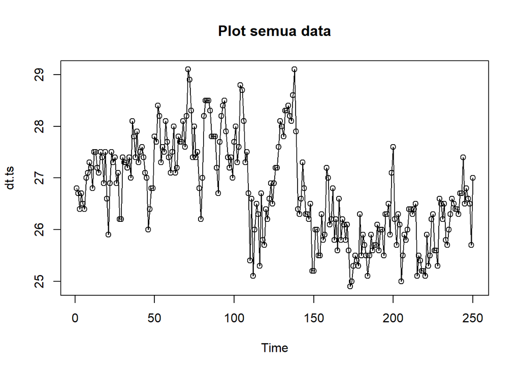

```r
#eksplorasi data
plot(dt.ts, col="black",main="Plot semua data")
points(dt.ts)
```

Data Latih

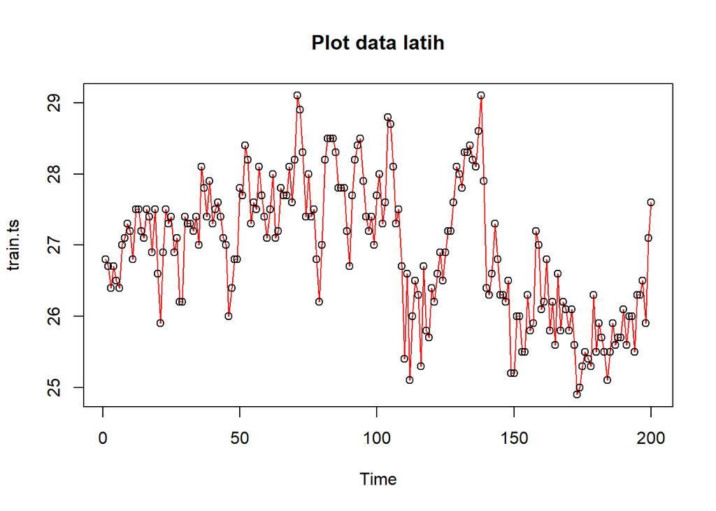

```r
plot(train.ts, col="red",main="Plot data latih")
points(train.ts)
```

Data Uji

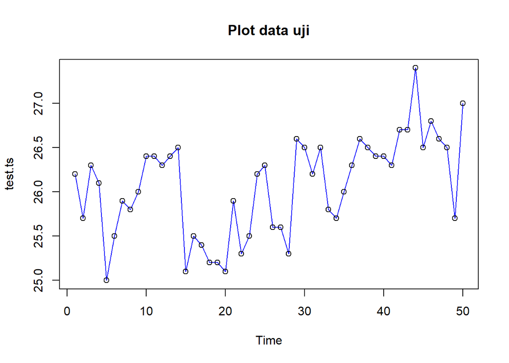

```r
plot(test.ts, col="blue",main="Plot data uji")
points(test.ts)
```

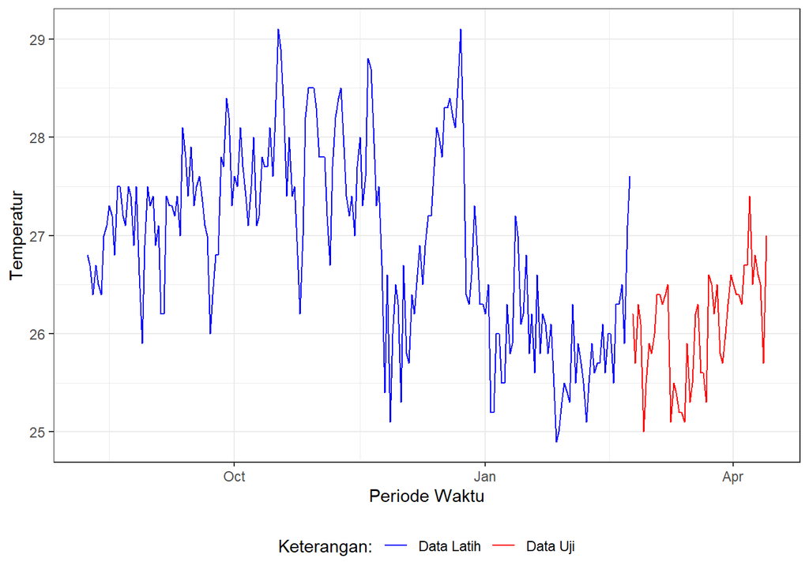

```r
#Eksplorasi dengan GGPLOT
library(ggplot2)
ggplot() +
  geom_line(data = training, aes(x = date, y = temp_mean, col = "Data Latih")) +
  geom_line(data = testing, aes(x = date, y = temp_mean, col = "Data Uji")) +
  labs(x = "Periode Waktu", y = "Temperatur", color = "Legend") +
  scale_colour_manual(name="Keterangan:", breaks = c("Data Latih", "Data Uji"),
                      values = c("blue", "red")) +
  theme_bw() + theme(legend.position = "bottom",
                     plot.caption = element_text(hjust=0.5, size=12))
```

Pemulusan dengan metode SES dapat dilakukan dengan dua fungsi dari packages berbeda, yaitu (1) fungsi ses() dari packages forecast dan (2) fungsi HoltWinters dari packages stats.

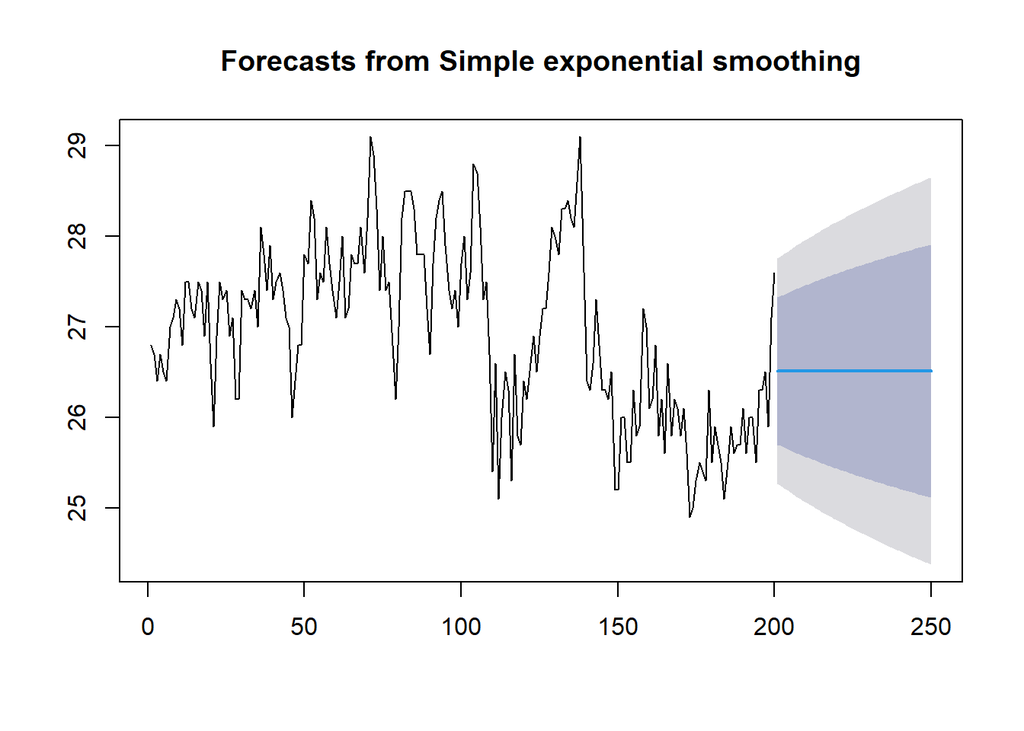

```r
#Cara 1 (fungsi ses)
ses.1 <- ses(train.ts, h = 50, alpha = 0.2)
plot(ses.1)
```

```r
ses.1
```

```
##     Point Forecast    Lo 80    Hi 80    Lo 95    Hi 95
## 201       26.51256 25.69964 27.32547 25.26931 27.75581
## 202       26.51256 25.68354 27.34157 25.24469 27.78043
## 203       26.51256 25.66775 27.35737 25.22053 27.80458
## 204       26.51256 25.65225 27.37287 25.19682 27.82829
## 205       26.51256 25.63702 27.38810 25.17354 27.85158
## 206       26.51256 25.62205 27.40306 25.15064 27.87447
## 207       26.51256 25.60733 27.41778 25.12813 27.89698
## 208       26.51256 25.59285 27.43227 25.10598 27.91913
## 209       26.51256 25.57859 27.44653 25.08417 27.94094
## 210       26.51256 25.56454 27.46057 25.06269 27.96242
## 211       26.51256 25.55070 27.47441 25.04152 27.98359
## 212       26.51256 25.53706 27.48806 25.02066 28.00446
## 213       26.51256 25.52360 27.50151 25.00008 28.02504
## 214       26.51256 25.51032 27.51479 24.97978 28.04534
```

[output cut: 36 more lines]

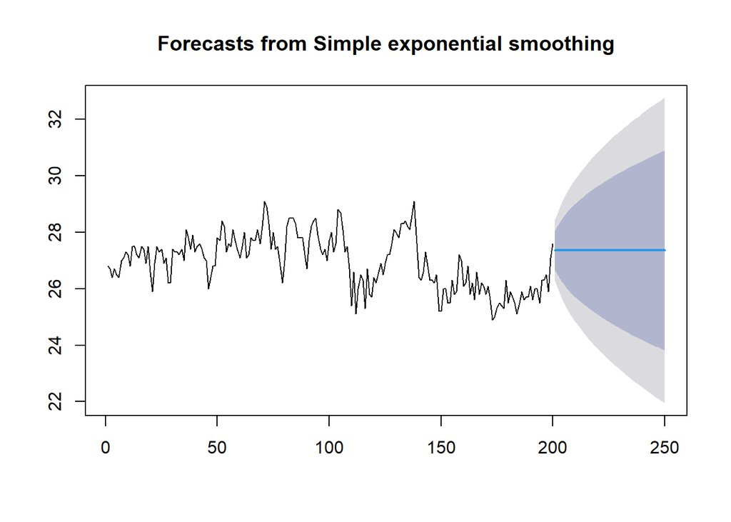

```r
ses.2<- ses(train.ts, h = 50, alpha = 0.7)
plot(ses.2)
```

```r
ses.2
```

```
##     Point Forecast    Lo 80    Hi 80    Lo 95    Hi 95
## 201        27.3561 26.64861 28.06360 26.27408 28.43812
## 202        27.3561 26.49249 28.21971 26.03533 28.67687
## 203        27.3561 26.36057 28.35163 25.83356 28.87864
## 204        27.3561 26.24419 28.46802 25.65557 29.05663
## 205        27.3561 26.13888 28.57332 25.49452 29.21768
## 206        27.3561 26.04199 28.67021 25.34634 29.36586
## 207        27.3561 25.95176 28.76044 25.20835 29.50385
## 208        27.3561 25.86700 28.84520 25.07871 29.63349
## 209        27.3561 25.78680 28.92540 24.95606 29.75614
## 210        27.3561 25.71051 29.00169 24.83939 29.87281
## 211        27.3561 25.63760 29.07460 24.72788 29.98432
## 212        27.3561 25.56766 29.14454 24.62092 30.09128
## 213        27.3561 25.50036 29.21184 24.51799 30.19421
## 214        27.3561 25.43541 29.27679 24.41866 30.29354
```

[output cut: 36 more lines]

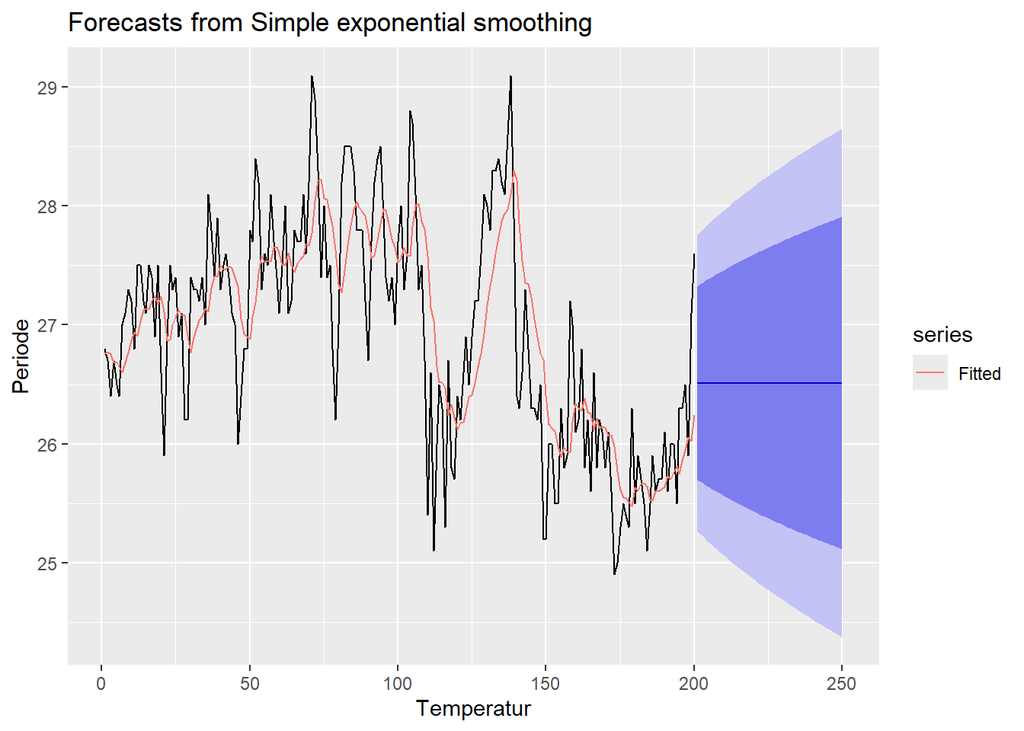

```r
autoplot(ses.1) +
  autolayer(fitted(ses.1), series="Fitted") +
  ylab("Periode") + xlab("Temperatur")
```

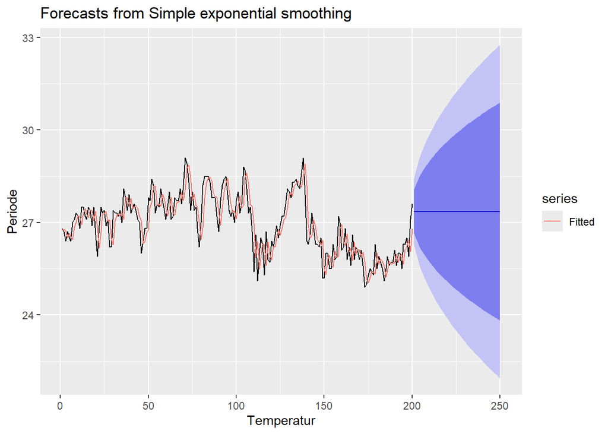

```r
autoplot(ses.2) +
  autolayer(fitted(ses.2), series="Fitted") +
  ylab("Periode") + xlab("Temperatur")
```

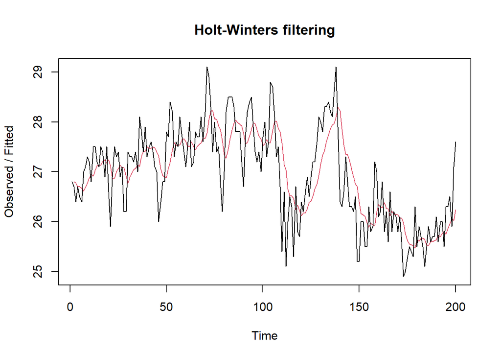

```r
#Cara 2 (fungsi Holtwinter)
ses1<- HoltWinters(train.ts, gamma = FALSE, beta = FALSE, alpha = 0.2)
plot(ses1)
```

```r
#ramalan
ramalan1<- forecast(ses1, h=50)
ramalan1
```

```
##     Point Forecast    Lo 80    Hi 80    Lo 95    Hi 95
## 201       26.51256 25.69967 27.32544 25.26936 27.75576
## 202       26.51256 25.68357 27.34154 25.24474 27.78038
## 203       26.51256 25.66778 27.35733 25.22059 27.80453
## 204       26.51256 25.65228 27.37283 25.19688 27.82823
## 205       26.51256 25.63705 27.38806 25.17359 27.85152
## 206       26.51256 25.62209 27.40303 25.15070 27.87441
## 207       26.51256 25.60737 27.41775 25.12819 27.89692
## 208       26.51256 25.59288 27.43223 25.10604 27.91908
## 209       26.51256 25.57862 27.44649 25.08423 27.94088
## 210       26.51256 25.56458 27.46053 25.06275 27.96236
## 211       26.51256 25.55074 27.47437 25.04158 27.98353
## 212       26.51256 25.53710 27.48802 25.02072 28.00440
## 213       26.51256 25.52364 27.50147 25.00014 28.02497
## 214       26.51256 25.51037 27.51475 24.97984 28.04528
```

[output cut: 36 more lines]

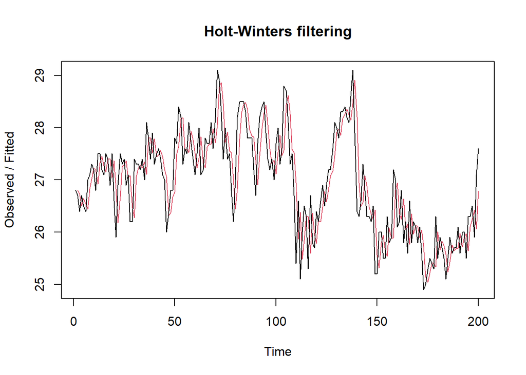

```r
ses2<- HoltWinters(train.ts, gamma = FALSE, beta = FALSE, alpha = 0.7)
plot(ses2)
```

```r
ramalan2<- forecast(ses2, h=50)
ramalan2
```

```
##     Point Forecast    Lo 80    Hi 80    Lo 95    Hi 95
## 201        27.3561 26.64861 28.06359 26.27408 28.43812
## 202        27.3561 26.49250 28.21970 26.03533 28.67687
## 203        27.3561 26.36057 28.35163 25.83357 28.87863
## 204        27.3561 26.24419 28.46801 25.65558 29.05662
## 205        27.3561 26.13888 28.57332 25.49453 29.21767
## 206        27.3561 26.04199 28.67021 25.34634 29.36586
## 207        27.3561 25.95177 28.76043 25.20836 29.50384
## 208        27.3561 25.86700 28.84520 25.07872 29.63348
## 209        27.3561 25.78681 28.92539 24.95607 29.75613
## 210        27.3561 25.71052 29.00169 24.83940 29.87281
## 211        27.3561 25.63761 29.07459 24.72789 29.98431
## 212        27.3561 25.56767 29.14453 24.62093 30.09127
## 213        27.3561 25.50037 29.21184 24.51800 30.19420
## 214        27.3561 25.43542 29.27678 24.41867 30.29353
```

[output cut: 36 more lines]

Nilai parameter α dari kedua fungsi dapat dioptimalkan menyesuaikan dari error-nya paling minimumnya. Caranya adalah dengan membuat parameter α=NULL .

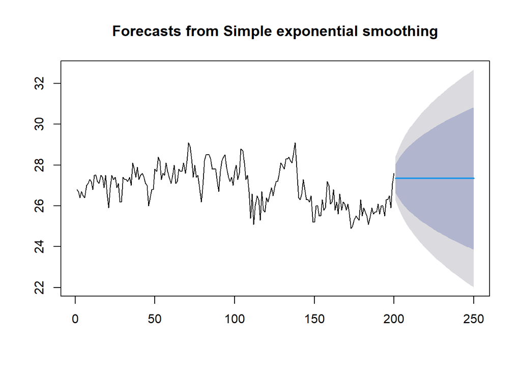

```r
#SES
ses.opt <- ses(train.ts, h = 50, alpha = NULL)
plot(ses.opt)
```

```r
ses.opt
```

```
##     Point Forecast    Lo 80    Hi 80    Lo 95    Hi 95
## 201       27.34434 26.63688 28.05181 26.26237 28.42632
## 202       27.34434 26.48510 28.20359 26.03024 28.65845
## 203       27.34434 26.35636 28.33233 25.83336 28.85533
## 204       27.34434 26.24257 28.44612 25.65932 29.02936
## 205       27.34434 26.13947 28.54921 25.50165 29.18703
## 206       27.34434 26.04453 28.64416 25.35645 29.33223
## 207       27.34434 25.95607 28.73262 25.22116 29.46753
## 208       27.34434 25.87291 28.81578 25.09398 29.59471
## 209       27.34434 25.79421 28.89448 24.97362 29.71507
## 210       27.34434 25.71931 28.96937 24.85908 29.82961
## 211       27.34434 25.64772 29.04096 24.74959 29.93910
## 212       27.34434 25.57903 29.10965 24.64453 30.04415
## 213       27.34434 25.51292 29.17577 24.54342 30.14527
## 214       27.34434 25.44911 29.23958 24.44583 30.24286
```

[output cut: 36 more lines]

```r
#Lamda Optimum Holt Winter
HWopt<- HoltWinters(train.ts, gamma = FALSE, beta = FALSE,alpha = NULL)
HWopt
```

```
## Holt-Winters exponential smoothing without trend and without seasonal component.
##
## Call:
## HoltWinters(x = train.ts, alpha = NULL, beta = FALSE, gamma = FALSE)
##
## Smoothing parameters:
##  alpha: 0.6895479
##  beta : FALSE
##  gamma: FALSE
##
## Coefficients:
##       [,1]
## a 27.34463
```

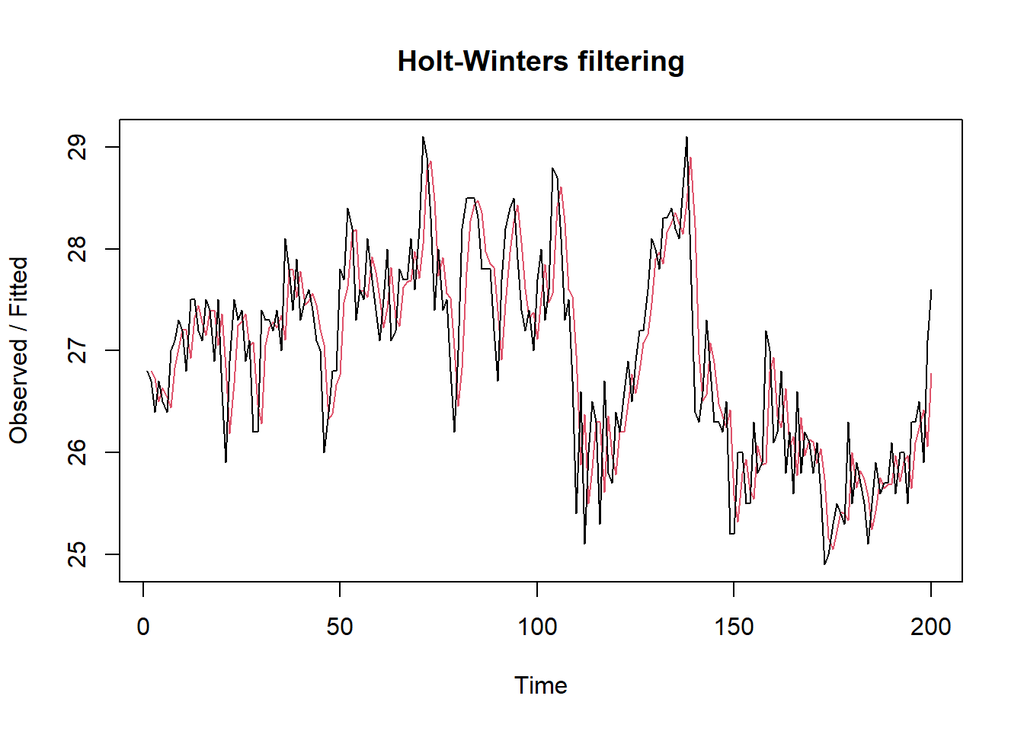

```r
plot(HWopt)
```

```r
#ramalan
ramalanopt<- forecast(HWopt, h=50)
ramalanopt
```

```
##     Point Forecast    Lo 80    Hi 80    Lo 95    Hi 95
## 201       27.34463 26.63716 28.05209 26.26265 28.42660
## 202       27.34463 26.48528 28.20398 26.03036 28.65889
## 203       27.34463 26.35647 28.33279 25.83337 28.85589
## 204       27.34463 26.24261 28.44664 25.65924 29.03002
## 205       27.34463 26.13946 28.54979 25.50149 29.18777
## 206       27.34463 26.04447 28.64478 25.35622 29.33304
## 207       27.34463 25.95597 28.73329 25.22086 29.46840
## 208       27.34463 25.87277 28.81648 25.09362 29.59563
## 209       27.34463 25.79404 28.89522 24.97320 29.71605
## 210       27.34463 25.71911 28.97015 24.85861 29.83064
## 211       27.34463 25.64749 29.04177 24.74907 29.94018
## 212       27.34463 25.57877 29.11049 24.64398 30.04528
## 213       27.34463 25.51262 29.17663 24.54282 30.14644
## 214       27.34463 25.44878 29.24047 24.44518 30.24407
```

[output cut: 36 more lines]

Akurasi Data Latih

```r
#Keakuratan Metode
#Pada data training

# SES dengan alpha = 0.2
SSE1<-ses1$SSE
MSE1<-ses1$SSE/length(train.ts)
RMSE1<-sqrt(MSE1)

akurasi1 <- matrix(c(SSE1,MSE1,RMSE1))
row.names(akurasi1)<- c("SSE", "MSE", "RMSE")
colnames(akurasi1) <- c("Akurasi lamda=0.2")
akurasi1
```

```
##      Akurasi lamda=0.2
## SSE         79.6722342
## MSE          0.3983612
## RMSE         0.6311586
```

```r
# SES dengan alpha = 0.7
SSE2<-ses2$SSE
MSE2<-ses2$SSE/length(train.ts)
RMSE2<-sqrt(MSE2)

akurasi2 <- matrix(c(SSE2,MSE2,RMSE2))
row.names(akurasi2)<- c("SSE", "MSE", "RMSE")
colnames(akurasi2) <- c("Akurasi lamda=0.7")
akurasi2
```

```
##      Akurasi lamda=0.7
## SSE         60.3475061
## MSE          0.3017375
## RMSE         0.5493064
```

```r
#Cara Manual
# Alpha = 0.2
fitted1<-ramalan1$fitted
sisaan1<-ramalan1$residuals
head(sisaan1)
```

```
## Time Series:
## Start = 1
## End = 6
## Frequency = 1
## [1]       NA -0.10000 -0.38000 -0.00400 -0.20320 -0.26256
```

```r
resid1<-training$temp_mean-ramalan1$fitted
head(resid1)
```

```
## Time Series:
## Start = 1
## End = 6
## Frequency = 1
## [1]       NA -0.10000 -0.38000 -0.00400 -0.20320 -0.26256
```

```r
SSE.1=sum(sisaan1[2:length(train.ts)]^2)
SSE.1
```

```
## [1] 79.67223
```

```r
MSE.1 = SSE.1/length(train.ts)
MSE.1
```

```
## [1] 0.3983612
```

```r
MAPE.1 = sum(abs(sisaan1[2:length(train.ts)]/train.ts[2:length(train.ts)])*
               100)/length(train.ts)
MAPE.1
```

```
## [1] 1.812037
```

```r
akurasi.1 <- matrix(c(SSE.1,MSE.1,MAPE.1))
row.names(akurasi.1)<- c("SSE", "MSE", "MAPE")
colnames(akurasi.1) <- c("Akurasi lamda=0.2")
akurasi.1
```

```
##      Akurasi lamda=0.2
## SSE         79.6722342
## MSE          0.3983612
## MAPE         1.8120371
```

akurasi pada ses1 menggunakan nilai MAPE menghasilkan nilai MAPE **< 2%** sehingga dikategorikan sangat baik.

```r
# Alpha = 0.7
fitted2<-ramalan2$fitted
sisaan2<-ramalan2$residuals
head(sisaan2)
```

```
## Time Series:
## Start = 1
## End = 6
## Frequency = 1
## [1]       NA -0.10000 -0.33000  0.20100 -0.13970 -0.14191
```

```r
resid2<-training$temp_mean-ramalan2$fitted
head(resid2)
```

```
## Time Series:
## Start = 1
## End = 6
## Frequency = 1
## [1]       NA -0.10000 -0.33000  0.20100 -0.13970 -0.14191
```

```r
SSE.2=sum(sisaan2[2:length(train.ts)]^2)
SSE.2
```

```
## [1] 60.34751
```

```r
MSE.2 = SSE.2/length(train.ts)
MSE.2
```

```
## [1] 0.3017375
```

```r
MAPE.2 = sum(abs(sisaan2[2:length(train.ts)]/train.ts[2:length(train.ts)])*
               100)/length(train.ts)
MAPE.2
```

```
## [1] 1.605333
```

```r
akurasi.2 <- matrix(c(SSE.2,MSE.2,MAPE.2))
row.names(akurasi.2)<- c("SSE", "MSE", "MAPE")
colnames(akurasi.2) <- c("Akurasi lamda=0.7")
akurasi.2
```

```
##      Akurasi lamda=0.7
## SSE         60.3475061
## MSE          0.3017375
## MAPE         1.6053332
```

Berdasarkan nilai SSE, MSE, RMSE, dan MAPE di antara kedua parameter pada data latih, nilai parameter **lambda=0,7** menghasilkan akurasi yang lebih baik dibanding **lambda=0,2** . Hal ini dilihat dari nilai masing-masing ukuran akurasi yang lebih kecil. Berdasarkan nilai MAPE-nya, hasil ini dapat dikategorikan sebagai peramalan sangat baik.

Akurasi Data Uji

```r
# jumlah observasi uji
n_test <- nrow(testing)

# error (ramalan - aktual), samakan panjang dan tipe numeric
e1   <- as.numeric(ramalan1$mean)[1:n_test] - as.numeric(testing$temp_mean)
e2   <- as.numeric(ramalan2$mean)[1:n_test] - as.numeric(testing$temp_mean)
eopt <- as.numeric(ramalanopt$mean)[1:n_test] - as.numeric(testing$temp_mean)

# SSE / MSE / RMSE untuk masing-masing model (abaikan NA)
SSEtesting1  <- sum(e1^2,  na.rm = TRUE)
MSEtesting1  <- mean(e1^2, na.rm = TRUE)
RMSEtesting1 <- sqrt(MSEtesting1)

SSEtesting2  <- sum(e2^2,  na.rm = TRUE)
MSEtesting2  <- mean(e2^2, na.rm = TRUE)
RMSEtesting2 <- sqrt(MSEtesting2)

SSEtestingopt  <- sum(eopt^2,  na.rm = TRUE)
MSEtestingopt  <- mean(eopt^2, na.rm = TRUE)
RMSEtestingopt <- sqrt(MSEtestingopt)

# Tabel ringkas
akurasitesting_SSE <- matrix(c(SSEtesting1, SSEtesting2, SSEtestingopt),
                             nrow = 3,
                             dimnames = list(c("SSE1","SSE2","SSEopt"), "Nilai"))
akurasitesting_MSE <- matrix(c(MSEtesting1, MSEtesting2, MSEtestingopt),
                             nrow = 3,
                             dimnames = list(c("MSE1","MSE2","MSEopt"), "Nilai"))
akurasitesting_RMSE <- matrix(c(RMSEtesting1, RMSEtesting2, RMSEtestingopt),
                              nrow = 3,
                              dimnames = list(c("RMSE1","RMSE2","RMSEopt"), "Nilai"))

akurasitesting_SSE
```

```
##           Nilai
## SSE1   24.87033
## SSE2   97.94895
## SSEopt 96.47769
```

```r
akurasitesting_MSE
```

```
##            Nilai
## MSE1   0.4974065
## MSE2   1.9589789
## MSEopt 1.9295538
```

```r
akurasitesting_RMSE
```

```
##             Nilai
## RMSE1   0.7052705
## RMSE2   1.3996353
## RMSEopt 1.3890838
```

```r
MAPE1 <- sum(abs(e1[1:n_test] / testing$temp_mean) * 100) / n_test
MAPE2 <- sum(abs(e2[1:n_test] / testing$temp_mean) * 100) / n_test
MAPEopt <- sum(abs(eopt[1:n_test] / testing$temp_mean) * 100) / n_test

# Buat tabel ringkas
akurasitesting_MAPE <- matrix(c(MAPE1, MAPE2, MAPEopt),
                              nrow = 3,
                              dimnames = list(c("MAPE1","MAPE2","MAPEopt"), "Nilai"))

# Cek hasil
akurasitesting_MAPE
```

```
##            Nilai
## MAPE1   2.090709
## MAPE2   4.994207
## MAPEopt 4.951851
```

Berdasarkan nilai SSE, MSE, dan RMSE di antara kedua parameter pada data uji, nilai parameter **lambda=0,2** menghasilkan akurasi yang lebih baik dibanding **lambda=0,2** dan lamba optimum. Hal ini dilihat dari nilai masing-masing ukuran akurasi yang lebih kecil. Berdasarkan nilai MAPE-nya, hasil ini dapat dikategorikan sebagai peramalan sangat baik.

Berdasarkan hasil analisis metode Simple Exponential Smoothing (SES), terlihat bahwa pemilihan nilai parameter λ berpengaruh besar terhadap performa model. Pada data latih, λ = 0.7 maupun λ optimal (0.689) memberikan nilai error lebih kecil dibanding λ = 0.2 sehingga secara statistik tampak lebih baik. Namun, ketika diuji pada data uji, justru λ = 0.2 menghasilkan nilai SSE, MSE, dan RMSE yang lebih rendah, menunjukkan kemampuan generalisasi yang lebih baik. Selain itu, secara visual, pemulusan dengan λ = 0.2 juga lebih halus dan stabil dibandingkan λ yang lebih besar, sehingga pola data lebih mudah diinterpretasikan. Dengan demikian, meskipun λ optimal secara matematis mendekati 0.7, pemilihan λ = 0.2 lebih tepat digunakan karena mampu menghasilkan peramalan yang lebih akurat di data uji dan memberikan hasil pemulusan yang lebih baik secara visual

Double Exponential Smoothing

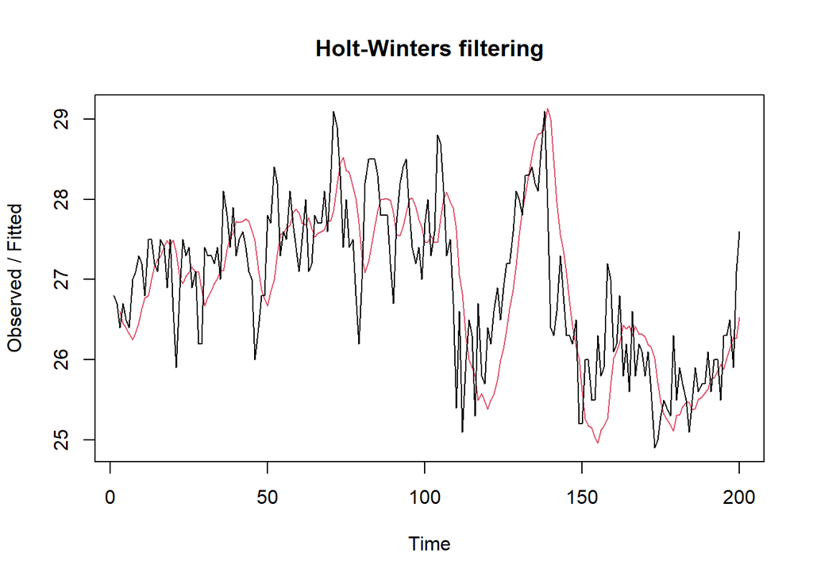

```r
#Lamda=0.2 dan gamma=0.2
des.1<- HoltWinters(train.ts, gamma = FALSE, beta = 0.2, alpha = 0.2)
plot(des.1)
```

```r
#ramalan
ramalandes1<- forecast(des.1, h=50)
ramalandes1
```

```
##     Point Forecast    Lo 80    Hi 80    Lo 95    Hi 95
## 201       26.87748 25.96176 27.79320 25.47700 28.27796
## 202       27.01385 26.07213 27.95558 25.57361 28.45410
## 203       27.15022 26.17422 28.12623 25.65755 28.64290
## 204       27.28660 26.26755 28.30564 25.72810 28.84510
## 205       27.42297 26.35193 28.49401 25.78495 29.06099
## 206       27.55934 26.42740 28.69129 25.82818 29.29050
## 207       27.69571 26.49420 28.89723 25.85815 29.53328
## 208       27.83209 26.55269 29.11148 25.87542 29.78875
## 209       27.96846 26.60332 29.33359 25.88067 30.05625
## 210       28.10483 26.64656 29.56310 25.87460 30.33507
## 211       28.24120 26.68286 29.79955 25.85792 30.62448
## 212       28.37757 26.71267 30.04248 25.83132 30.92383
## 213       28.51395 26.73641 30.29149 25.79543 31.23246
## 214       28.65032 26.75444 30.54620 25.75082 31.54981
```

[output cut: 36 more lines]

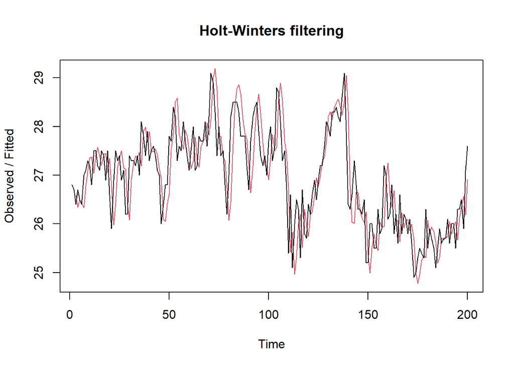

```r
#Lamda=0.6 dan gamma=0.3
des.2<- HoltWinters(train.ts, gamma = FALSE, beta = 0.3, alpha = 0.6)
plot(des.2)
```

```r
#ramalan
ramalandes2<- forecast(des.2, h=50)
ramalandes2
```

```
##     Point Forecast    Lo 80    Hi 80       Lo 95    Hi 95
## 201       27.62756 26.84721 28.40790 26.43412327 28.82099
## 202       27.93068 26.94103 28.92034 26.41713981 29.44423
## 203       28.23381 26.99260 29.47502 26.33554014 30.13208
## 204       28.53694 27.00986 30.06402 26.20146673 30.87241
## 205       28.84007 26.99806 30.68207 26.02295821 31.65717
## 206       29.14319 26.96074 31.32565 25.80542037 32.48097
## 207       29.44632 26.90039 31.99225 25.55265674 33.33999
## 208       29.74945 26.81885 32.68005 25.26747736 34.23142
## 209       30.05258 26.71752 33.38763 24.95205104 35.15310
## 210       30.35570 26.59756 34.11385 24.60811414 36.10329
## 211       30.65883 26.45989 34.85778 24.23709880 37.08056
## 212       30.96196 26.30530 35.61862 23.84021494 38.08370
## 213       31.26509 26.13448 36.39569 23.41850474 39.11167
## 214       31.56821 25.94803 37.18840 22.97288009 40.16355
```

[output cut: 36 more lines]

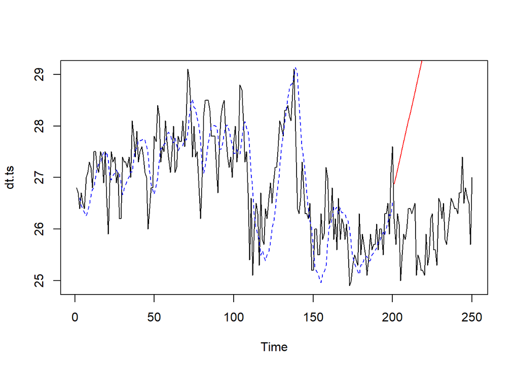

```r
plot(dt.ts)
lines(des.1$fitted[,1], lty=2, col="blue")
lines(ramalandes1$mean, col="red")
```

```r
#Lamda dan gamma optimum
des.opt<- HoltWinters(train.ts, gamma = FALSE)
des.opt
```

```
## Holt-Winters exponential smoothing with trend and without seasonal component.
##
## Call:
## HoltWinters(x = train.ts, gamma = FALSE)
##
## Smoothing parameters:
##  alpha: 0.7174639
##  beta : 0.0135813
##  gamma: FALSE
##
## Coefficients:
##           [,1]
## a 27.372617153
## b  0.004769482
```

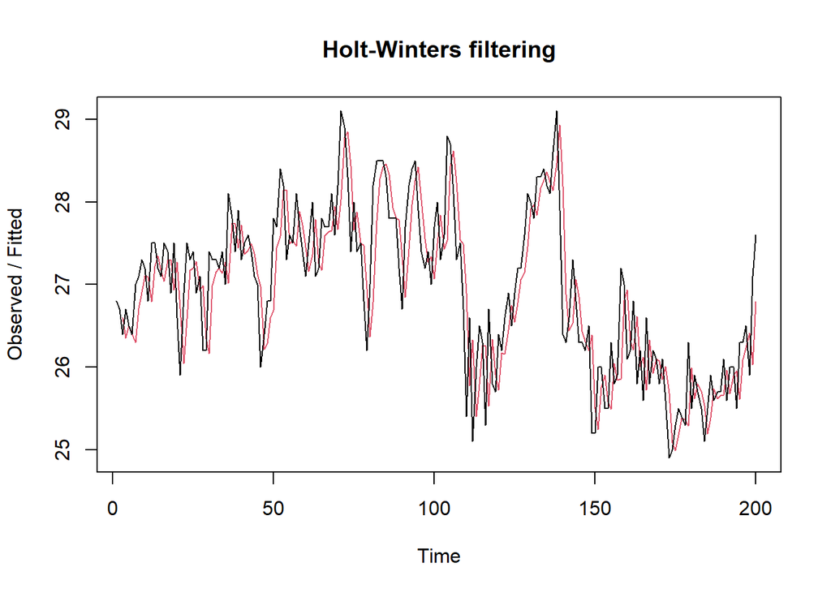

```r
plot(des.opt)
```

```r
#ramalan
ramalandesopt<- forecast(des.opt, h=50)
ramalandesopt
```

```
##     Point Forecast    Lo 80    Hi 80    Lo 95    Hi 95
## 201       27.37739 26.66213 28.09264 26.28350 28.47127
## 202       27.38216 26.49777 28.26654 26.02961 28.73470
## 203       27.38693 26.35738 28.41648 25.81237 28.96149
## 204       27.39170 26.23186 28.55153 25.61789 29.16550
## 205       27.39646 26.11664 28.67629 25.43915 29.35378
## 206       27.40123 26.00902 28.79345 25.27203 29.53044
## 207       27.40600 25.90725 28.90476 25.11385 29.69815
## 208       27.41077 25.81013 29.01142 24.96280 29.85875
## 209       27.41554 25.71680 29.11429 24.81753 30.01355
## 210       27.42031 25.62660 29.21402 24.67707 30.16355
## 211       27.42508 25.53905 29.31111 24.54064 30.30952
## 212       27.42985 25.45374 29.40596 24.40765 30.45206
## 213       27.43462 25.37035 29.49889 24.27760 30.59164
## 214       27.43939 25.28864 29.59014 24.15010 30.72868
```

[output cut: 36 more lines]

Akurasi Data Latih

```r
#Akurasi Data Training
ssedes.train1<-des.1$SSE
msedes.train1<-ssedes.train1/length(train.ts)
sisaandes1<-ramalandes1$residuals
head(sisaandes1)
```

```
## Time Series:
## Start = 1
## End = 6
## Frequency = 1
## [1]         NA         NA -0.2000000  0.2480000  0.0964800  0.0714048
```

```r
mapedes.train1 <- sum(abs(sisaandes1[3:length(train.ts)]/train.ts[3:length(train.ts)])
                      *100)/length(train.ts)

akurasides.1 <- matrix(c(ssedes.train1,msedes.train1,mapedes.train1))
row.names(akurasides.1)<- c("SSE", "MSE", "MAPE")
colnames(akurasides.1) <- c("Akurasi lamda=0.2 dan gamma=0.2")
akurasides.1
```

```
##      Akurasi lamda=0.2 dan gamma=0.2
## SSE                      100.7587625
## MSE                        0.5037938
## MAPE                       2.0398005
```

```r
ssedes.train2<-des.2$SSE
msedes.train2<-ssedes.train2/length(train.ts)
sisaandes2<-ramalandes2$residuals
head(sisaandes2)
```

```
## Time Series:
## Start = 1
## End = 6
## Frequency = 1
## [1]         NA         NA -0.2000000  0.3560000  0.0143200 -0.0249296
```

```r
mapedes.train2 <- sum(abs(sisaandes2[3:length(train.ts)]/train.ts[3:length(train.ts)])
                      *100)/length(train.ts)

akurasides.2 <- matrix(c(ssedes.train2,msedes.train2,mapedes.train2))
row.names(akurasides.2)<- c("SSE", "MSE", "MAPE")
colnames(akurasides.2) <- c("Akurasi lamda=0.6 dan gamma=0.3")
akurasides.2
```

```
##      Akurasi lamda=0.6 dan gamma=0.3
## SSE                        73.066197
## MSE                         0.365331
## MAPE                        1.753283
```

```r
# Akurasi Data Training DES OPT
ssedes.train.opt <- des.opt$SSE
msedes.train.opt <- ssedes.train.opt / length(train.ts)

sisaandesopt <- ramalandesopt$residuals
mapedes.train.opt <- sum(abs(sisaandesopt[3:length(train.ts)]/train.ts[3:length(train.ts)])*100) / length(train.ts)

akurasides.opt <- matrix(c(ssedes.train.opt, msedes.train.opt, mapedes.train.opt))
row.names(akurasides.opt) <- c("SSE", "MSE", "MAPE")
colnames(akurasides.opt) <- c("Akurasi DES Opt")
akurasides.opt
```

```
##      Akurasi DES Opt
## SSE       61.9478405
## MSE        0.3097392
## MAPE       1.6271690
```

Hasil akurasi dari data latih didapatkan des.opt memiliki hasil yang lebih baik. Namun untuk ketiga skenario dapat dikategorikan peramalan sangat baik berdasarkan nilai MAPE-nya.

Akurasi Data Uji

```r
#Akurasi Data Testing
selisihdes1<-ramalandes1$mean-testing$temp_mean
selisihdes1
```

```
## Time Series:
## Start = 201
## End = 250
## Frequency = 1
##  [1] 0.6774796 1.3138519 0.8502242 1.1865965 2.4229688 2.0593411 1.7957134
##  [8] 2.0320857 1.9684580 1.7048303 1.8412025 2.0775748 2.1139471 2.1503194
## [15] 3.6866917 3.4230640 3.6594363 3.9958086 4.1321809 4.3685532 3.7049255
## [22] 4.4412978 4.3776701 3.8140423 3.8504146 4.6867869 4.8231592 5.2595315
## [29] 4.0959038 4.3322761 4.7686484 4.6050207 5.4413930 5.6777653 5.5141376
## [36] 5.3505098 5.1868821 5.4232544 5.6596267 5.7959990 6.0323713 5.7687436
## [43] 5.9051159 5.3414882 6.3778605 6.2142328 6.5506051 6.7869773 7.7233496
## [50] 6.5597219
```

```r
SSEtestingdes1<-sum(selisihdes1^2)
MSEtestingdes1<-SSEtestingdes1/length(testing$temp_mean)
MAPEtestingdes1<-sum(abs(selisihdes1/testing$temp_mean)*100)/length(testing$temp_mean)

selisihdes2<-ramalandes2$mean-testing$temp_mean
selisihdes2
```

```
## Time Series:
## Start = 201
## End = 250
## Frequency = 1
##  [1]  1.427556  2.230684  1.933811  2.436939  3.840066  3.643194  3.546321
##  [8]  3.949449  4.052576  3.955704  4.258831  4.661959  4.865086  5.068214
## [15]  6.771342  6.674469  7.077597  7.580724  7.883852  8.286979  7.790107
## [22]  8.693234  8.796362  8.399489  8.602617  9.605745  9.908872 10.512000
## [29]  9.515127  9.918255 10.521382 10.524510 11.527637 11.930765 11.933892
## [36] 11.937020 11.940148 12.343275 12.746403 13.049530 13.452658 13.355785
## [43] 13.658913 13.262040 14.465168 14.468295 14.971423 15.374550 16.477678
## [50] 15.480806
```

```r
SSEtestingdes2<-sum(selisihdes2^2)
MSEtestingdes2<-SSEtestingdes2/length(testing$temp_mean)
MAPEtestingdes2<-sum(abs(selisihdes2/testing$temp_mean)*100)/length(testing$temp_mean)

selisihdesopt<-ramalandesopt$mean-testing$temp_mean
selisihdesopt
```

```
## Time Series:
## Start = 201
## End = 250
## Frequency = 1
##  [1] 1.1773866 1.6821561 1.0869256 1.2916951 2.3964646 1.9012340 1.5060035
##  [8] 1.6107730 1.4155425 1.0203120 1.0250815 1.1298509 1.0346204 0.9393899
## [15] 2.3441594 1.9489289 2.0536984 2.2584678 2.2632373 2.3680068 1.5727763
## [22] 2.1775458 1.9823152 1.2870847 1.1918542 1.8966237 1.9013932 2.2061627
## [29] 0.9109321 1.0157016 1.3204711 1.0252406 1.7300101 1.8347796 1.5395490
## [36] 1.2443185 0.9490880 1.0538575 1.1586270 1.1633964 1.2681659 0.8729354
## [43] 0.8777049 0.1824744 1.0872439 0.7920133 0.9967828 1.1015523 1.9063218
## [50] 0.6110913
```

```r
SSEtestingdesopt<-sum(selisihdesopt^2)
MSEtestingdesopt<-SSEtestingdesopt/length(testing$temp_mean)
MAPEtestingdesopt<-sum(abs(selisihdesopt/testing$temp_mean)*100)/length(testing$temp_mean)

akurasitestingdes <-
  matrix(c(SSEtestingdes1,MSEtestingdes1,MAPEtestingdes1,SSEtestingdes2,MSEtestingdes2,
           MAPEtestingdes2,SSEtestingdesopt,MSEtestingdesopt,MAPEtestingdesopt),
         nrow=3,ncol=3)
row.names(akurasitestingdes)<- c("SSE", "MSE", "MAPE")
colnames(akurasitestingdes) <- c("des ske1","des ske2","des opt")
akurasitestingdes
```

```
##        des ske1   des ske2    des opt
## SSE  1017.39616 4892.38061 115.093475
## MSE    20.34792   97.84761   2.301869
## MAPE   15.89656   34.36050   5.515256
```

Bandingan Semua Metode

```r
# =======================
# Gabungan Data Training
# =======================

akurasi.train <- data.frame(
  Metode = c("SMA", "DMA", "SES1", "DES Opt"),
  SSE = c(SSE_train.sma,
          SSE_train.dma,
          SSE.1,
          ssedes.train.opt),
  MSE = c(MSE_train.sma,
          MSE_train.dma,
          MSE.1,
          msedes.train.opt),
  MAPE = c(MAPE_train.sma,
           MAPE_train.dma,
           MAPE.1,
           mapedes.train.opt)
)
akurasi.train
```

```
##    Metode      SSE       MSE     MAPE
## 1     SMA 74.89500 0.3821173 1.806962
## 2     DMA 92.22447 0.4778470 2.028496
## 3    SES1 79.67223 0.3983612 1.812037
## 4 DES Opt 61.94784 0.3097392 1.627169
```

```r
# ======================
# Gabungan Data Testing
# ======================

akurasi.test <- data.frame(
  Metode = c("SMA", "DMA", "SES1", "DES Opt"),
  SSE = c(SSE_test.sma,
          SSE_test.dma,
          SSEtesting1,        # <- PAKAI yang ini
          SSEtestingdesopt),
  MSE = c(MSE_test.sma,
          MSE_test.dma,
          MSEtesting1,        # <- PAKAI yang ini
          MSEtestingdesopt),
  MAPE = c(MAPE_test.sma,
           MAPE_test.dma,
           MAPE1,      # <- PAKAI yang ini
           MAPEtestingdesopt)
)

akurasi.test
```

```
##    Metode        SSE        MSE      MAPE
## 1     SMA   39.98125  0.7996250  2.885945
## 2     DMA 3246.49963 64.9299925 28.092372
## 3    SES1   24.87033  0.4974065  2.090709
## 4 DES Opt  115.09347  2.3018695  5.515256
```

Berdasarkan hasil perbandingan metode peramalan menggunakan data training dan testing, diperoleh bahwa pada data training metode Double Exponential Smoothing (DES Opt) memberikan hasil terbaik dengan nilai error terkecil pada SSE, MSE, dan MAPE dibandingkan metode lainnya.

Namun, ketika diuji menggunakan data testing, performa DES Opt mengalami penurunan yang cukup signifikan dengan error yang relatif tinggi sehingga kurang konsisten dalam memprediksi data baru. Hal ini mungkin mengindikasikan adanya overfitting di metode DES Opt, yaitu kondisi dimana bagus di data training, namun jelek di data testing.

Sebaliknya, metode Single Exponential Smoothing (SES1) yaitu dengan lamda 0.2 menunjukkan performa yang stabil, walaupun pada data training hasilnya tidak selalu paling baik, tetapi pada data testing justru memberikan error terkecil dan paling akurat.